# Risques chimiques. Stockage des produits chimiques - Risques - INRS

Accès rapides :

Navigation transversale :

[Santé et sécurité au travail](https://www.inrs.fr/)

Recherche rapide :

Mots-clés recherchés :

dossier :

# Risques chimiques

Sommaire du dossier

Vous êtes ici :

# Stockage des produits chimiques

Un stockage défaillant peut s’avérer lourd de conséquences : réactions chimiques dangereuses, dégagement important de produits nocifs, voire explosion ou incendie, intoxication, chute de plain-pied, blessures… De nombreux paramètres jouent un rôle dans la sécurité du stockage :

- la quantité des produits stockés ;
- la présence de produits volatils, inflammables ou incompatibles entre eux ou avec les matériaux présents ;
- la ventilation ;
- l’arrimage des emballages ;
- la stabilité des produits et des emballages aux variations de température, aux rayonnements…

[figure not shown]

Principes fondamentaux du stockage des produits chimiques (animation)

anim 47

##### Différentes situations de stockage de produits en entreprise

[figure not shown]

- © Claude Almodovar pour l'INRS – 2009

  Zone de stockage ventilée et de préparation de peintures

[figure not shown]

- © Grégoire Maisonneuve pour l'INRS – 2012

  Pièce de stockage des produits chimiques

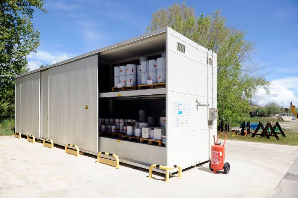

- © Patrick Delapierre pour l'INRS – 2012

  Container de stockage de produits en extérieur pour des raisons de sécurité incendie

[figure not shown]

- © Patrick Delapierre pour l'INRS – 2019

  Armoire de stockage avec bacs de rétention pour les produits de nettoyage d’une entreprise

[figure not shown]

- © Claude Almodovar pour l'INRS – 2009

  Zone de stockage ventilée et de préparation de peintures

[figure not shown]

- © Grégoire Maisonneuve pour l'INRS – 2012

  Pièce de stockage des produits chimiques
- - 1
  - 2
  - 3
  - 4

### Bien entreposer pour protéger

Au-delà de sa fonction de « magasin », le lieu de stockage a pour vocation première de limiter l’exposition aux risques associés à ces produits chimiques et de soustraire les personnes aux effets d’un dégagement involontaire ou d’une réaction chimique spontanée.

Afin de limiter les quantités de produits chimiques aux postes de travail tout en garantissant une activité continue, le stockage peut être organisé en un local central et un ou plusieurs lieux de stockage dits « tampons » à proximité des postes de travail. L’utilisation des lieux de stockage doit être soumise à des règles strictes, dont l’application doit être contrôlée régulièrement par un responsable compétent.

Lieux de stockage des produits chimiques : quelques règles d’organisation

- Limiter l’accès au stockage aux seules personnes formées et autorisées.
- Tenir à jour un état du stock.
- Subordonner le stockage d’un produit à l’existence de sa fiche de données de sécurité et de son étiquetage.
- Mettre en place un classement rigoureux et connu (affichage d’un plan, interdiction d’entreposer des emballages volumineux ou lourds en hauteur, pas d’entreposage d’outillage et de matériel dans le local de stockage de produits chimiques…).
- Instaurer une règle de déstockage « premier entré / premier sorti ».
- Respecter les dates de péremption de produits.
- Mettre en place une procédure d’élimination des produits inutiles ou périmés.
- Interdire l’encombrement des voies d’accès, des issues et équipements de secours.

Quelle que soit leur taille, les lieux de stockage sont à concevoir et à aménager en tenant compte non seulement des propriétés physico-chimiques des produits, mais aussi des types de contenants qui y seront entreposés, du nombre de personnes devant y avoir accès, de la quantité de produits consommée… Il faut également anticiper les besoins liés au stockage des **déchets chimiques** en vue de leur élimination.

### Signalisation

Les lieux de stockage doivent être clairement identifiés. Des **panneaux d’avertissement** doivent figurer à l’entrée comme par exemple « Matières inflammables », « Matières corrosives », « Matières toxiques »…

Outre le **plan de stockage** (localisation des différents produits, capacité maximale…) peuvent être également prévus l’**affichage** d’un récapitulatif de l’étiquetage des produits entreposés et le rappel des incompatibilités éventuelles.

### Séparation des produits incompatibles / réactions dangereuses

Certains produits peuvent réagir les uns avec les autres, provoquant parfois des explosions, des incendies, des projections ou des émissions de gaz dangereux. Ces produits incompatibles doivent être séparés physiquement.

D’autres produits encore réagissent violemment avec l’eau : ils doivent être entreposés de façon à ce que tout contact avec de l’eau soit impossible, même en cas d’inondation.

Enfin, les **produits inflammables** doivent être stockés à part dans une enceinte dédiée et constamment ventilée.

### Prévention et lutte contre l’incendie

Un local de stockage de produits en quantités importantes doit être isolé du reste du bâtiment, afin d’éviter la propagation d’un incendie qui s’y déclarerait. De même, il doit être bâti à l’aide de matériaux durs et incombustibles et muni de systèmes d'évacuation et de lutte contre le feu appropriés (portes coupe-feu, extincteurs…). L’accès au local doit être facile, permettant une évacuation rapide en cas d’accident. Une localisation en sous-sol est à proscrire.

De même, l’**installation électrique** doit être réduite au minimum indispensable à l’intérieur du local et, selon les produits entreposés, être adaptée à une zone où peuvent apparaître accidentellement des atmosphères explosibles (éclairage étanche, par exemple).

### Prévention et lutte contre les dispersions accidentelles

Des capacités de rétention doivent être prévues par catégorie de produits. Le local de stockage doit lui-même être en rétention générale. Un **produit absorbant** approprié aux produits stockés (neutralisant, incombustible) doit être disponible dans le local de stockage, afin de récupérer fuites et gouttes de produits.

Suivant les résultats de l’évaluation des risques, un **appareil respiratoire isolant** (à entretenir et vérifier périodiquement) sera disposé à l’extérieur du local et à proximité de l’entrée et une douche de sécurité ainsi qu’une fontaine oculaire de secours seront accessibles à proximité immédiate.

### Ventilation et conditionnement d’air

Une **ventilation mécanique**, résistant à la corrosion et permettant de maintenir en permanence le local de stockage en dépression par rapport aux locaux adjacents, doit être prévue. Le débit de ventilation est à déterminer en fonction des produits stockés. Les entrées et sorties d’air doivent être placées de manière à évacuer le plus rapidement possible les polluants éventuels du local. L’air extrait par l’installation de ventilation doit être rejeté à l’extérieur des bâtiments en tenant compte des règles de protection de l’environnement.

Détermination du débit de ventilation

Le débit minimal de ventilation à mettre en œuvre peut être calculé en s’appuyant sur le respect de la [valeur limite d’exposition professionnelle1](https://www.inrs.fr/risques/mesure-expositions-agents-chimiques-biologiques/reglementation.html) sur 15 minutes et du dixième de la [limite inférieure d’explosivité2](https://www.inrs.fr/risques/explosion/conditions-survenue-consequences.html) des substances stockées. Ce débit calculé sera au besoin majoré pour le réglage de l’installation de ventilation afin d’atteindre un renouvellement d’air minimum du local de l’ordre d’un volume par heure.https://www.inrs.fr/risques/mesure-expositions-agents-chimiques-biologiques/reglementation.htmlhttps://www.inrs.fr/risques/explosion/conditions-survenue-consequences.html

La brochure [ED 6058, Évaluation de la vitesse d'évaporation et de la concentration d'un composé organique volatil dans l'atmosphère d'un local de travail3](https://www.inrs.fr/media.html?refINRS=ED+6058) propose une méthode de calcul de la concentration de vapeur dans l’atmosphère générée par l’évaporation d’un liquide organique volatil. Dans le contexte d’un local de stockage, cette concentration est notamment en relation avec la surface d’évaporation (remarque : en première approximation, en l’absence de données, il peut être considéré que la surface d’étalement d’un liquide avoisine 0,5 m<sup>2</sup> par litre), la pression de vapeur du liquide à la température de surface et la pression atmosphérique.https://www.inrs.fr/media.html?refINRS=ED+6058

**Exemple** : En prenant comme hypothèse le déversement d’un bidon de 5L d’[acétate de n-butyle4](https://www.inrs.fr/publications/bdd/fichetox/fiche.html?refINRS=FICHETOX_31) sur une surface de 2,5 m<sup>2</sup>, à la pression atmosphérique moyenne et à 20 °C, le débit minimum d’extraction d’air à mettre en place est alors de l’ordre de 300 m<sup>3</sup>/h.https://www.inrs.fr/publications/bdd/fichetox/fiche.html?refINRS=FICHETOX_31

Ce débit permet d’atteindre un renouvellement d’air de l’ordre de 20 volumes par heure pour un local d’un volume de 15 m<sup>3</sup> (6 m<sup>2</sup> de surface au sol et 2,5 m de hauteur au plafond). Si le volume du local de stockage, dans lequel un tel déversement pourrait avoir lieu, était de 480 m<sup>3</sup>(80 m<sup>2</sup> de surface au sol et 6 m de hauteur au plafond), ce débit calculé serait considéré comme insuffisant, l’installation de ventilation devrait alors être réglée sur un débit d’extraction de d’ordre de 500 m<sup>3</sup>/h au minimum.

Par ailleurs, le gel peut altérer un certain nombre de préparations et entraîner des ruptures de conditionnement. À l’inverse, une température élevée favorise des surpressions préjudiciables aux emballages et dangereuses lors de leur ouverture. En conséquence, des mesures doivent être prises pour maintenir la température du local à un niveau approprié.

[figure not shown]

© Gaël Kerbaol/INRS – 2011

Rayonnages métalliques dans une pièce de stockage de peintures

### Rayonnages

Les rayonnages doivent être réalisés en matériaux résistant mécaniquement et chimiquement. Leur stabilisation efficace doit empêcher tout **basculement**. Leur espacement doit être adapté à la circulation des personnes, voire d’équipements de manutention.

Les produits doivent être faciles d’accès et bien visibles : un éclairage suffisant (300 lux) est à prévoir à l’aplomb des allées.

##### Pour en savoir plus

- Ressources INRS
  - Vidéo Durée : 03min 07s

    [Le stockage des produits chimiques](https://www.inrs.fr/media.html?refINRS=Anim-047)

    [Ce film court sous la forme d'un roman photo fait passer quelques messages sur les principes fondamentaux du stockage des produits chimiques ; il fait la promotion de solutions simples et faciles à m... 5](https://www.inrs.fr/media.html?refINRS=Anim-047) https://www.inrs.fr/media.html?refINRS=Anim-047
  - Brochure 07/2017 | ED 753

    [Stockage et transfert des produits chimiques dangereux](https://www.inrs.fr/media.html?refINRS=ED%20753)

    [Cette brochure contient des informations de base sur les risques et les moyens de prévention lors du stockage et du transvasement des produits chimiques dangereux. Elle a été rédigée pour être facilement lue par des responsables d'entreprises n'ayant pas de connaissances particulières en chimie. A ... 6](https://www.inrs.fr/media.html?refINRS=ED%20753) https://www.inrs.fr/media.html?refINRS=ED%20753
  - Brochure 05/2019 | ED 6015

    [Le stockage des produits chimiques au laboratoire](https://www.inrs.fr/media.html?refINRS=ED%206015)

    [Le travail dans un laboratoire de chimie se caractérise par la manipulation et le stockage de produits chimiques très divers présentant toutes les catégories de danger (incendie, explosion, risques pour la santé). Ce document recense les mesures à prendre pour que ce stockage soit réalisé dans les ... 7](https://www.inrs.fr/media.html?refINRS=ED%206015) https://www.inrs.fr/media.html?refINRS=ED%206015
  - Brochure 06/2008 | ED 6032

    [Les absorbants industriels](https://www.inrs.fr/media.html?refINRS=ED%206032)

    [Dans les laboratoires, les ateliers et les usines surviennent chaque jour d'innombrables pollutions accidentelles aux causes multiples : incendie, erreur de manipulation, incident machine, ... Ces fuites et déversements peuvent compromettre l'ordre et la propreté dans l'entreprise et mettre en péril... 8](https://www.inrs.fr/media.html?refINRS=ED%206032) https://www.inrs.fr/media.html?refINRS=ED%206032
- Stockage des produits chimiques. Guide de bonnes pratiques en entreprise

Mis à jour le 05/01/2023

##### Voir aussi

- [Logiciel Seirich](https://www.inrs.fr/publications/outils/seirich.html)

  [Le logiciel Seirich permet aux entreprises de repérer, d’évaluer et de s’informer sur les produits chimiques utilisés dans l’entreprise. Il est téléchargeable sur seirich.fr](https://www.inrs.fr/publications/outils/seirich.html)
- [Programme Risques chimiques Pros](https://www.ameli.fr/entreprise/sante-travail/risques/risques-chimiques-entreprise/agir)

  [Assurance maladie - Risques professionnels](https://www.ameli.fr/entreprise/sante-travail/risques/risques-chimiques-entreprise/agir)
- Brochure

  [Le risque chimique](https://www.inrs.fr/media.html?refINRS=ED%206541)

  [La plupart des activités exposent les travailleurs au risque chimique. Cette brochure vous donne les clés pour construire une démarche de prévention des risques professionnels.](https://www.inrs.fr/media.html?refINRS=ED%206541)
- Brochure

  [Risque chimique. S'informer pour prévenir](https://www.inrs.fr/media.html?refINRS=ED%204705)

  [Ce catalogue vous propose l'essentiel de nos productions (brochures, dépliants, affiches, vidéos, pages et outils web...) sur les notions générales relatives à la prévention du risque chimique sur le lieu de travail.](https://www.inrs.fr/media.html?refINRS=ED%204705)
- [LinkedIn : INRS - Risques chimiques](https://www.linkedin.com/showcase/risques-chimiques)

  [Retrouvez toute l'actualité de la prévention du risque chimique sur la page LinkedIn de l'INRS](https://www.linkedin.com/showcase/risques-chimiques)

##### formations INRS

- [Tous les stages Risque chimique](https://www.inrs.fr/pages-de-recherche/recherche-stages-par-theme.html?themeStage=Risque%20chimique)

##### L'ESSENTIEL SUR...

- [L’ étiquetage des produits chimiques](https://www.inrs.fr/publications/essentiels/CLP.html)

  [Nouveaux pictogrammes, nouvelles classes de danger… Retrouvez toutes nos ressources pour vous aider à comprendre et mettre en place le système de classification et d'étiquetage des produits chimiques CLP (« Classification, Labelling and Packaging »).](https://www.inrs.fr/publications/essentiels/CLP.html)